# Лабораторная работа №2

Операционные системы

Малюга В. В.

Российский университет дружбы народов, Москва, Россия

1 марта 2024

## Цель работы

Изучить идеологию и применение средств контроля версий.  
Освоить умения по работе с git.

## Задание

1. Создать базовую конфигурацию для работы с git.
2. Создать ключ SSH.
3. Создать ключ PGP.
4. Настроить подписи git.
5. Зарегистрироваться на Github.
6. Создать локальный каталог для выполнения заданий по предмету.

## Выполнение лабораторной работы. Создание базовой конфигурации для работы с git

Установила git (рис. 1), gh (рис. 2).

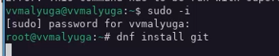

Установка git

## Выполнение лабораторной работы. Создание базовой конфигурации для работы с git

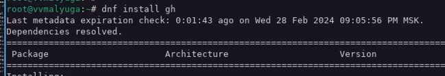

Установка gh

## Выполнение лабораторной работы. Создание базовой конфигурации для работы с git

Задала имя, email владельца репозитория, настроила utf-8 в выводе сообщений git, задала имя начальной ветки, параметры autocrlf и safecrlf (рис. 3).

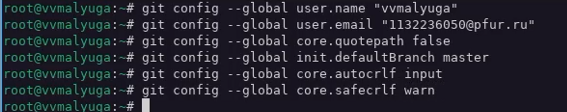

Базовая настройка git

## Выполнение лабораторной работы. Создание ключа SSH и PGP

Создала ключи ssh по алгоритму rsa с ключём размером 4096 бит и по алгоритму ed25519 (рис. 4). Создала ключи pgp по предложенным опциям (рис. 5).

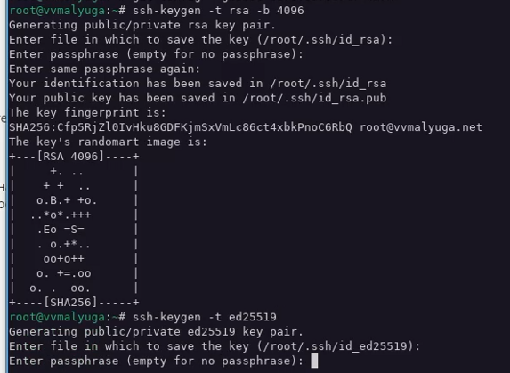

Создание ключей ssh

## Выполнение лабораторной работы. Создание ключа SSH и PGP

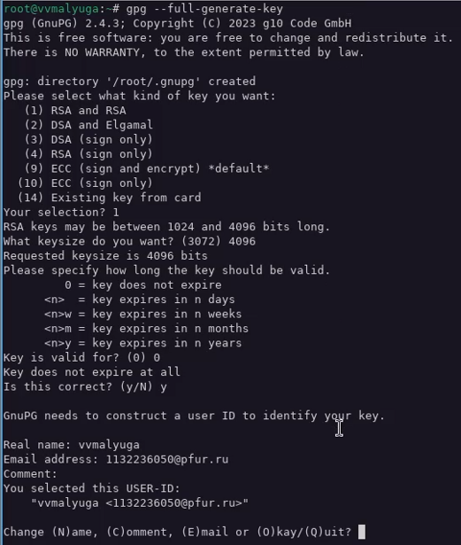

Создание ключей pgp

## Выполнение лабораторной работы. Создание ключа SSH и PGP

Вывела список ключей (рис. 6), затем вывела gpg ключ (рис. 7). Скопировала его, и авторизовала в гитхабе (рис. 8).

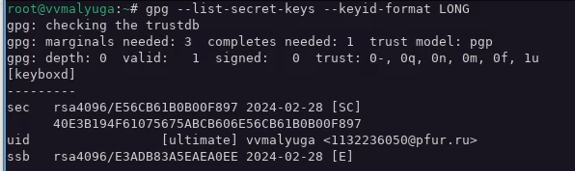

Вывод списка ключей

## Выполнение лабораторной работы. Создание ключа SSH и PGP

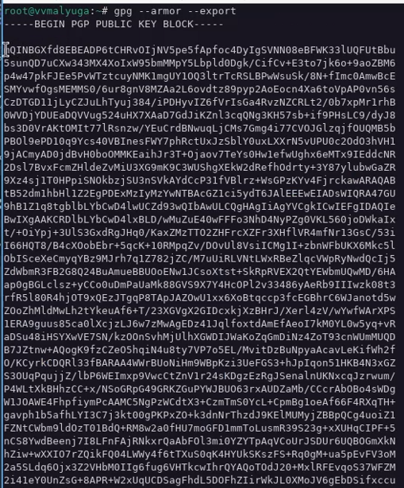

Вывод gpg ключа

## Выполнение лабораторной работы. Создание ключа SSH и PGP

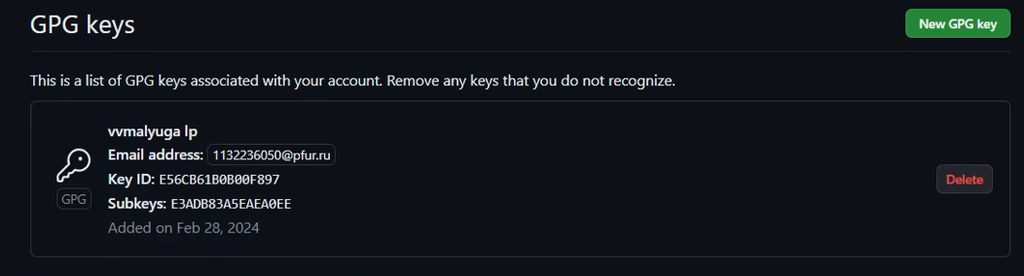

Авторизованный ключ на гитхабе

## Выполнение лабораторной работы. Настройка подписи git

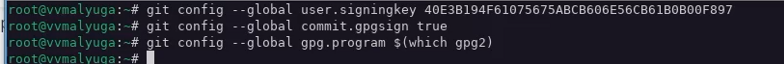

Настройка подписи git

## Выполнение лабораторной работы. Настройка gh

Авторизовала gh (рис. 10).

[figure not shown]

Авторизация gh

## Выполнение лабораторной работы. Создание репозитория курса на основе шаблона

Создала репозиторий курса на основе шаблона (рис. 11) и (рис. 12).

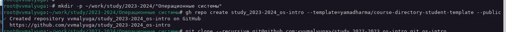

Создание репозитория

## Выполнение лабораторной работы. Создание репозитория курса на основе шаблона

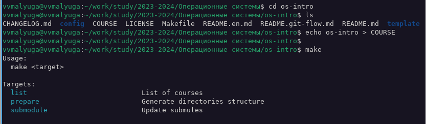

Создание репозитория

## Выполнение лабораторной работы. Создание репозитория курса на основе шаблона

Отправила файлы на сервер (рис. 13) и (рис. 14).

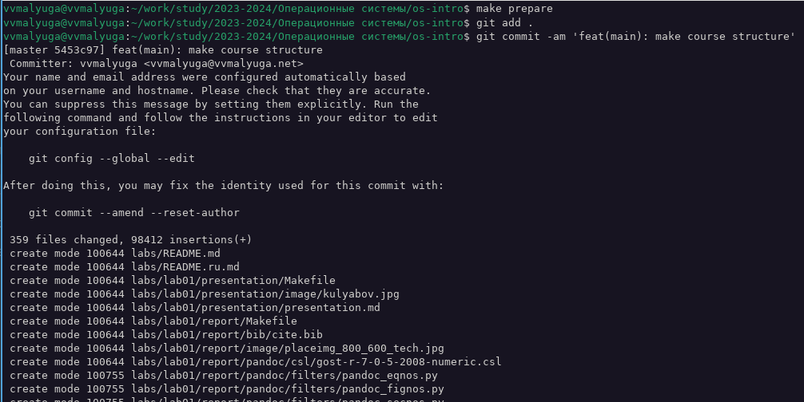

Настройка каталогов курса

## Выполнение лабораторной работы. Создание репозитория курса на основе шаблона

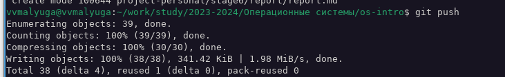

Отправка файлов на сервер

## Выводы

Изучила идеологию и применение средств контроля версий, освоила умения по работе с git.